# Week 2

David Kane

Go to https://registrar.fas.harvard.edu/faculty-staff/courses/enrollment and scroll down to “Access the Current Course Enrollment Numbers.” Click on that to download the Excel file. Create a folder in your project called `raw_data`. Move the Excel file into that folder. Be cool and do these things from the command line!

Load **tidyverse**, **readxl** and **janitor** into your setup chunk. You may need to install the packages **readxl** and **janitor** if you haven’t already.

### Scene 1

**Prompt:** Use **readxl** to read in the data and store it in an object called `raw`. Clean the data by cleaning any column names, skipping or cutting rows, and storing the cleaned data in an object called `en_fall_2020`. Additionally, since we will be looking only at undergraduate enrollment, get rid of any irrelevant columns, and filter to keep only courses with at least ten undergraduate students. This will get rid of any weird research courses. Look closely at your data! There is a lot of garbage to find and deal with.

Once you have finished cleaning your data, figure out the course with the highest enrollment. And figure out how many students are enrolled in Gov 50. If you get a number much lower than 151, you have done something wrong . . .

```r
raw <- readxl::read_xlsx(path = "raw_data/class_enrollment_summary_by_term_9-17-2020.xlsx", skip = 3)

en_fall_2020 <- raw %>%
  clean_names() %>%
  select(course_id, course_title, course_name, course_department, u_grad) %>%
  filter(u_grad >= 10) %>%
  drop_na() %>%
  arrange(desc(u_grad))

en_fall_2020
```

```
## # A tibble: 554 x 5
##    course_id course_title course_name            course_department        u_grad
##    <chr>     <chr>        <chr>                  <chr>                     <dbl>
##  1 113326    ECON 10A     Principles of Economi… Economics                   559
##  2 152514    COMPSCI 50   Intro to Computer Sci… Computer Science            504
##  3 110766    STAT 110     Introduction to Proba… Statistics                  433
##  4 123941    PSY 1        Intro. to Psychol. Sc… Psychology                  270
##  5 108901    ECON 1010A   Intermediate Microeco… Economics                   262
##  6 212765    GENED 1001   Stories from End of W… General Education           253
##  7 111010    MATH 1B      Calculus, Series, and  Mathematics                 253
##  8 216258    GENED 1171   Justice: Ethics in Pa… General Education           230
##  9 121189    LIFESCI 1A   Intro to Life Science… Molecular & Cellular Bi…    225
## 10 119196    MATH 21A     Multivariable Calculus Mathematics                 224
## # … with 544 more rows
```

```r
gov_50_enrollment <- en_fall_2020 %>%
  filter(course_title == "GOV 50")

gov_50_enrollment
```

```
## # A tibble: 2 x 5
##   course_id course_title course_name course_department u_grad
##   <chr>     <chr>        <chr>       <chr>              <dbl>
## 1 115859    GOV 50       Data        Government           110
## 2 115859    GOV 50       Data        Government            41
```

### Scene 2

**Prompt:** Create a bar plot of the 10 biggest courses. Order the plot so that courses appear in descending order. You will want to use coord_flip() to make your plot easy to read.

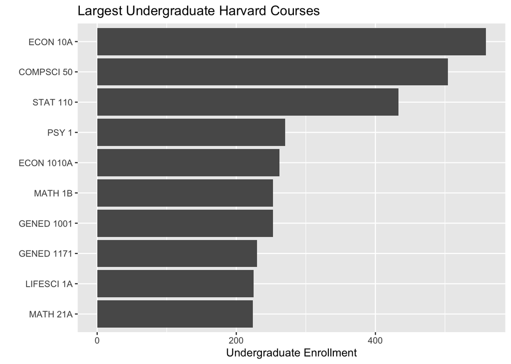

```r
en_fall_2020 %>%
  slice(1:10) %>%
  ggplot(aes(x = fct_reorder(course_title, u_grad), y = u_grad)) +
  geom_col() +
  coord_flip() +
  labs(title = "Largest Undergraduate Harvard Courses", x = "", y = "Undergraduate Enrollment")
```

### Scene 3

**Prompt:** Make a bar plot of total enrollment by department for the ten smallest departments. Arrange the bar plot in ascending order.

### Scene 4

**Prompt:** Create a scatterplot of the length of course name versus enrollment for the Computer Science and Economics Department. Use `nchar()` to find the length, and include spaces. Add a linear line of best fit on your plot and scale axes appropriately.